# Recruiting Veterans and Military Family Members Improves Confidence in Elections

Draft

Authors

Affiliations

Isaiah

Research Fellow, Center for Democracy and Civic Engagement

Michael J. Hanmer, PhD

Director, Center for Democracy and Civic Engagement

Published

2024-9-12

Modified

2024-10-15

Keywords

Election Workers, Poll workers, Veterans, Public opinion, Election administration

**Note**

You are reading a work-in-progress.

# Introduction

This report presents results from a survey experiment designed to examine how information that election officials are hiring veterans and military family members for the elections workforce influences the public’s attitudes about elections. The survey was developed by the Center for Democracy and Civic Engagement ([CDCE](https://cdce.umd.edu/)) at the University of Maryland (UMD) in consultation from [We the Veterans and Military Families](https://www.wetheveterans.us/). The survey was fielded from August 29 through September 9, 2024 on a sample of 1,263 US citizens of voting age purchased from Lucid and drawn to be representative of the US adult citizen population[^1].

After answering several background questions, participants were randomly assigned to read one of two vignettes we described as short excerpts from news stories. These vignettes were not from actual news stories, but they were modeled after relevant published articles. Both vignettes were set in Maricopa County, AZ and explained that local election officials were seeking to expand the elections workforce in advance of the upcoming presidential elections. We chose Maricopa County, AZ because it was a place where election administration was under close scrutiny in 2020 and could be again in 2024.

The vignette of primary interest focused on the recruitment of veterans and military family members from the local community to serve in elections jobs (VMF recruitment), while the comparison condition focused on a standard recruitment of people from the local community without reference to any populations to which they might belong (standard recruitment). Due to the randomization into conditions, any differences in responses can be attributed to the inclusion of information about veterans and military family members[^2]. The text of the treatment and control conditions appears in the Appendix.

We examined the potential effect of the treatment on a variety of attitudes about elections in Maricopa County, AZ such as confidence, concern about the potential for violence, and expectations of fraud. **Across all of the questions we asked, information about the recruitment of veterans and military family members to elections jobs led to improved outcomes. The implications are clear—elections officials who are recruiting veterans and military family members should publicize this fact and those who are not doing this recruitment should do so.**

The results also lead to the recommendation that election officials seek information about the status of their current workforce, full-time and temporary alike, as members of the VMF community. Given the usual age composition of individuals who sign up to be poll workers, it is highly likely that many served in the military themselves or members of their immediate family have done so. That is, it is likely that our elections workforce is already populated with veterans and military family members. Where this is the case, our results suggest that publicizing this information can help increase confidence in elections.

[^1]: It is important to note that because the sample is a non-probability sample, we focus on the differences across the conditions into which respondents were randomly assigned rather than the overall estimates for either group or the combined groups. Non-probability sampling uses non-random ways to select a group of people to participate in a research study or survey.
[^2]: It is worth emphasizing that the differences between the VMF recruitment vignette and Standard Recruitment vignette are minimal. The former refers to a program designed to recruit veterans and their family members and describes the interviewee “Jordan Braxton” as an Army veteran; whereas the latter vignette simply omits any mention of veterans and their family members, and doesn’t describe “Jordan Braxton” as an Army veteran. Beyond those small differences and the headlines, the article vignettes are identical. Thus, the effects discussed throughout this study refer to the effect of this difference.

# Results

## Trust and Confidence in Election Process and Administration

One of the most widely used questions in the study of attitudes about election administration asks how confident the respondent is that votes will be counted as intended. This question gets to the fundamental issue of how the process translates the voter’s behavior into the outcome.

Figure 1 shows that **information that election officials are recruiting veterans and military family members (VMF recruitment) boosts the rate at which respondents indicate they are very confident that votes in Maricopa County, AZ will be counted as intended by 7 percentage points, from 30% to 37% (p<0.025, one-tailed**[^3]).

Here’s how to read Figure 1 and all other plots like it. The question text that was presented to survey participants is displayed on top of the plot (i.e., bar graph). The horizontal bars represent the proportion of the sample separated according to which phony article (i.e., vignette) was read; either the `VMF Recruitment` vignette or the `Standard Recruitment` vignette. The bottom of the graph tells us that there were 624 who read the `Standard Recruitment` vignette, and 639 who read the `VMF Recruitment` vignette. Each horizontal bar is cut into four boxes that reflect the four response choices for the question and the percentage values inside each box represent the proportion of the sample in that group who chose the associated response. For instance, for those in the `Standard Recruitment` condition, 30% said they were “Very confident” and 49% said they were “Somewhat confident” that votes would be counted as voters intend. The percentage value on the far right (79%) represents the combined proportion of “Very confident” and “Somewhat confident” responses in the `Standard Recruitment` group condition. The percentage value on the far left (21%) represents the combined proportion of “Not at all confident” and “Not too confident” responses for that same group.

Figure 1: Confidence Votes will be Counted as Intended by Condition (VMF recruitment vs. Standard Recruitment)

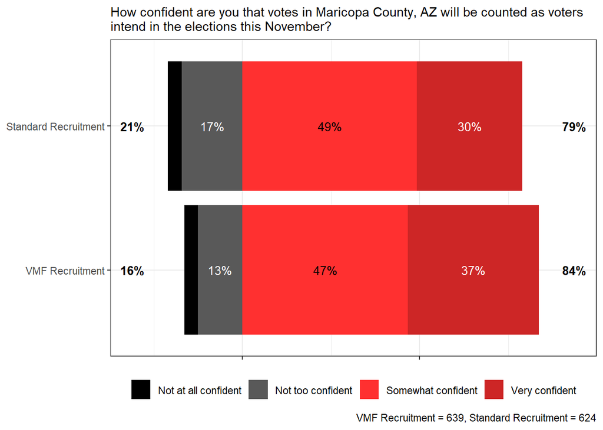

Importantly, the effects are generally even larger among those expected to be the most skeptical. For example, **among those who said that they thought Joe Biden’s election to president was not legitimate, exposure to information about veterans and military family members increases confidence overall by 15 percentage points from 60% to 75% (p<0.025)**. The bulk of this increase is driven by a shift in the rate at which respondents feel very confident, going from 9% in the control (community) condition to 19% in the treatment (veterans) condition. The following figures illustrate these results.

Figure 2: Confidence in Vote Count by Beliefs of 2020 Election Legitimacy and Recruitment Program

[figure not shown]

Veterans and military family members are also regarded highly by the public for their commitment. *Respondents were more likely to say the elections workforce would be very committed to making sure the elections held this November are fair and accurate when they heard that veterans and military family members were being recruited to elections jobs (by 9 percentage points, p<0.01)*.

Figure 3: Confidence in Commitment of Election Staff and Volunteers by Condition (VMF recruitment vs. Standard Recruitment)

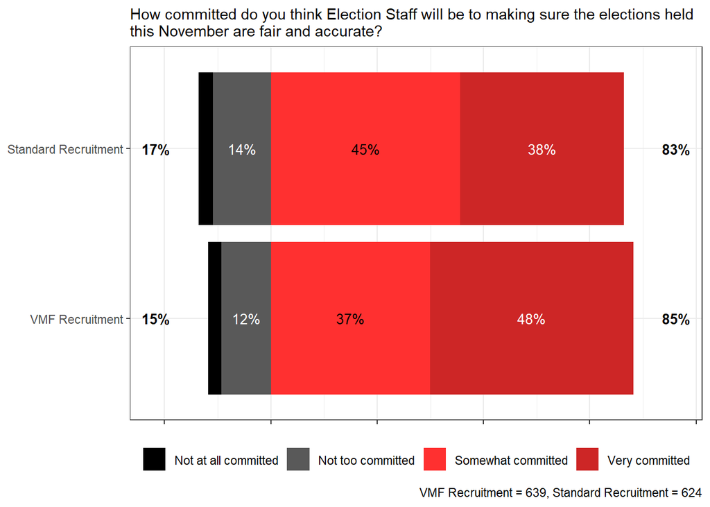

As shown in Figure 3, this increase is especially noteworthy as it brings the percentage of those saying very committed to nearly 50% (from just under 38.5% % to 48%).

**Information that election officials were recruiting veterans and military family members also increased confidence that the voting process in Maricopa County, AZ would be fair (by 7 percentage points, p<0.01)**.

Figure 4: Confidence in Fair Voting Process by Condition (VMF recruitment vs. Standard Recruitment)

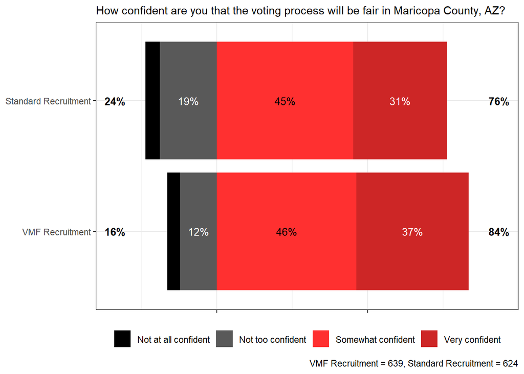

The bulk of this shift comes from an increase in the percentage of people saying they were very confident (6 points, p<0.025). **Again, the treatment effect was largest for those who said that Joe Biden was not elected legitimately**. Whereas 57% of those saying Biden’s victory was not legitimate were confident in the control (community) condition, confidence rose 16 percentage points to 73% among those who believe Biden’s election was not legitimate in the treatment (veterans) condition.

Figure 5: Confidence in Fair Voting Process in Maricopa County, AZ by Beliefs of 2020 Election Legitimacy and Recruitment Program

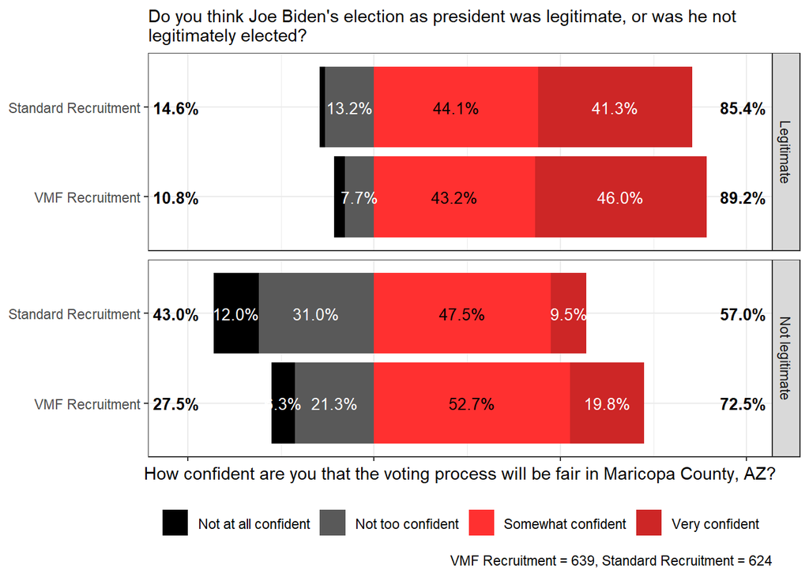

Although outcomes are subject to a wider variety of factors, the veterans treatment also increased confidence that the outcomes would be fair (by 4 percentage points, p<0.05), with a shift of 7 percentage points in the percentage saying they were very confident (p<0.025).

Figure 6: Confidence in Fair Voting Outcomes by Condition (VMF recruitment vs. Standard Recruitment)

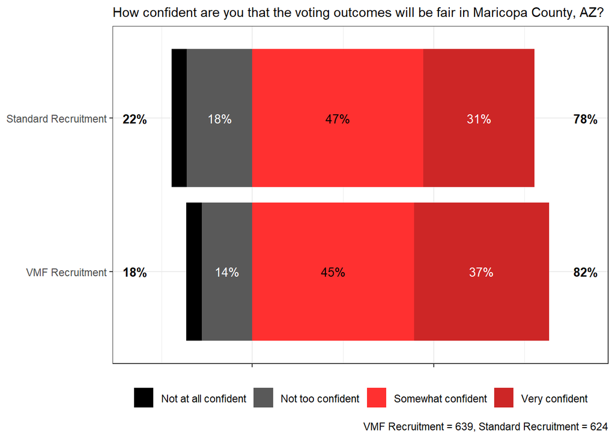

### Trust and Confidence in Election Security and Voter Safety

Attitudes relating to election security and safety were also improved as a result of exposure to information that veterans and military family members were being recruited to elections jobs. **The percentage saying they were confident the election would be secure from hacking and other technological threats was 7 points higher (p<0.01) in the veterans condition**.

Figure 7: Trust in Election Systems Tech by Condition (VMF recruitment vs. Standard Recruitment)

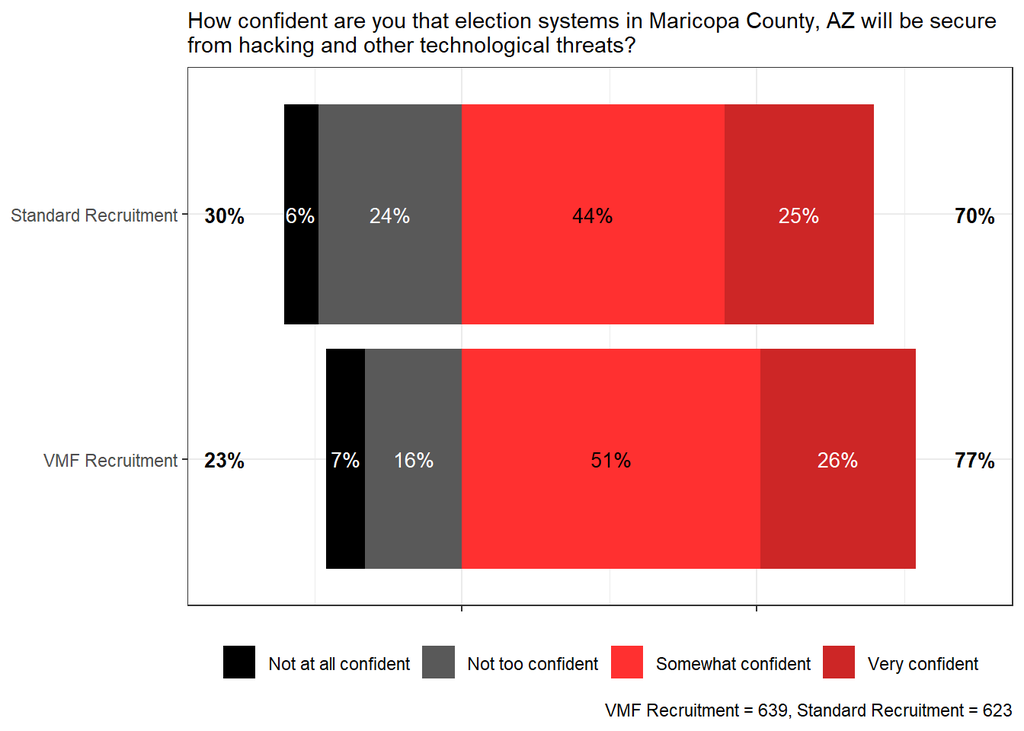

We assessed concerns for violence by asking how concerned voters in Maricopa County, AZ should feel about potential violence, threats of violence, or intimidation while voting in person at their local polling place. The level of concern with potential violence, threats, and intimidation was considerably lower (by 8 percentage points, p<0.01) among those who read that veterans and military family members were being recruited to the elections workforce. **In other words, concerns over the prospect of violence, threats of violence, and voter intimidation at election polling sites was far lower among those who were given information that veterans and their family members are being recruited to work as election staff compared to those who were given information that made no mention of veterans and family members.**

Figure 8: Concern for violence, threats, or voter intimidation in Maricopa County, AZ by Condition (VMF recruitment vs. Standard Recruitment)

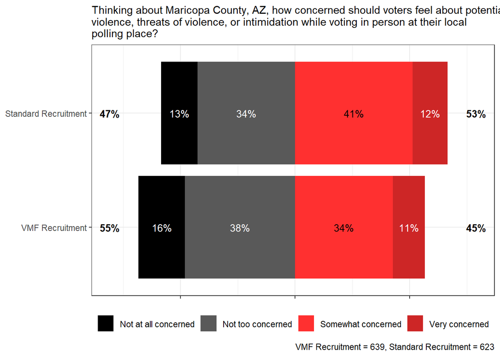

The size of this effect is especially significant because it brings the level of concern (“Somewhat concerned” and “Very concerned”) below the 50% mark. That is, while a majority (53%) of those who read about a standard election staff recruitment program were at least somewhat concerned, concerns for violence drop down to 45% among those who learned that officials of Maricopa County, AZ launched a program designed specifically to recruit veterans and family members. Additionally, those who learned about the VMF recruitment program were more likely to say they were confident that polling places would be safe places for voting in-person by 7 percentage points (p<0.01).

Figure 9: In-person voter safety in Maricopa County, AZ by Condition (VMF recruitment vs. Standard Recruitment)

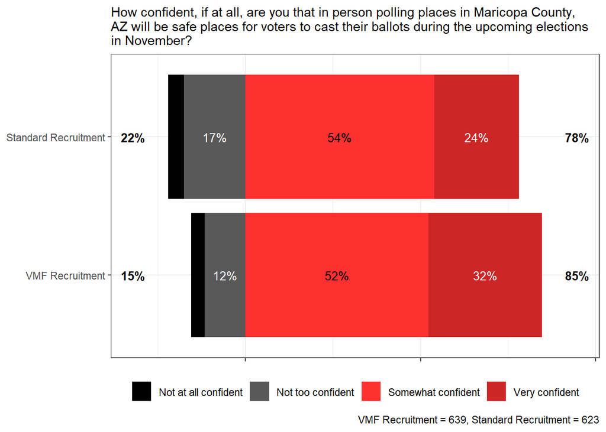

Note the nuanced distinction between the survey questions of Figure 8 and Figure 9: the former asks how concerned *the voters of Maricopa County, AZ should be* about violence, etc., whereas the latter asks for the respondent’s personal judgement of *how safe it will be in Maricopa County, AZ* to cast a vote in-person. These two survey items use slightly different questions to inquire about the same essential attitude—i.e., perceptions of voter safety at the polls. While there were still a hefty proportion of concern over the prospect of violence and voter safety at the polls across the board, these results suggest that special efforts to recruit veterans and their family members to work as election staff and volunteers eases such concerns quite significantly.

Learning that Maricopa County, AZ was recruiting veterans and military family members for elections jobs also led to improved performance ratings for election officials there. In the veterans condition, those saying they somewhat or strongly approve of the way election officials are handling their jobs was 5 percentage points higher (p<0.05), driven by a nearly 8 point increase in the percentage saying they strongly approve of election officials (p<0.01).

Figure 10: Approval of Election Officials in Maricopa County, AZ by Condition (VMF recruitment vs. Standard Recruitment)

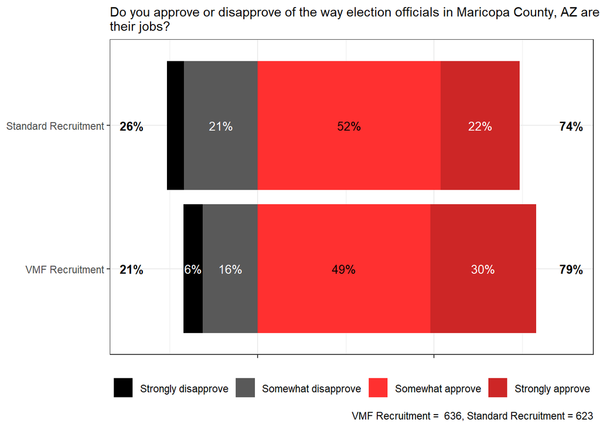

We also asked a general question about confidence that Maricopa County, AZ elections officials would do a good job conduction elections this November. Those who read about veterans and military family members were more confident that election officials would do a good job conducting the election than those who read about community members (by 4.5 percentage points, p <0.05).

Figure 11: Confidence Election Officials in Maricopa County, AZ will do a good job by Condition (VMF recruitment vs. Standard Recruitment)

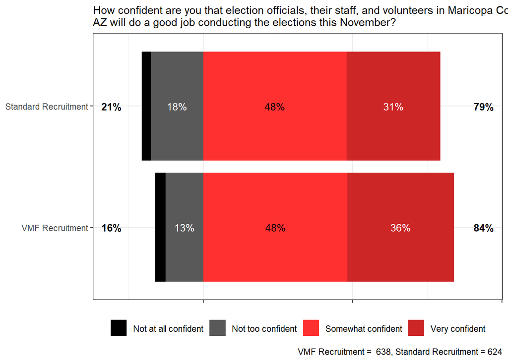

Before asking a series of questions about election administration in their own community, we asked how much respondents would like to see their local community adopt a program for recruiting elections staff similar to the one they read about in Maricopa County, AZ. Among those in the community condition just under 73% said their local area should probably or definitely adopt the policy compared to over 77% in the veterans condition (difference of 5 percentage points, p<0.03). The difference is driven entirely by an increase in enthusiasm (i.e., the likelihood of saying definitely should adopt is 5 points higher in the veterans condition, p<0.025).

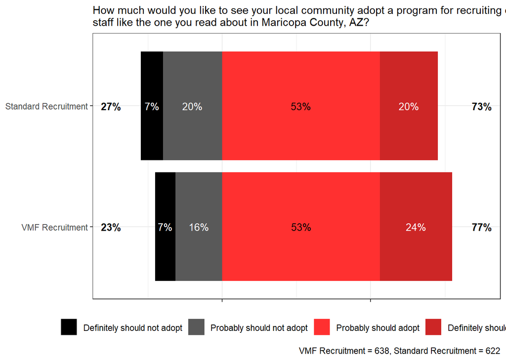

[^3]: **All p-values are 1 tailed as we have clear hypotheses that outcomes will be improved when respondents are exposed to information about the recruitment of veterans and military family members.**

## Expectation of Electoral Fraud

Our survey also asked respondents a series of questions designed to assess an individual’s expectation of electoral fraud and voter suppression in Maricopa County, AZ. Five statements were prefaced with the question, “How likely do you think any or all of the following will happen during this year´s elections in Maricopa County, AZ?”. Survey participants gave their expectations of the likelihood that each of the following would occur in Maricopa County, Arizona this election cycle on a scale of “Not likely at all”, “Not too likely”, “Somewhat likely”, and “Very likely”.

1. There will be voter fraud, that is, people who are not eligible to vote will vote, or vote more than once;
2. Many votes will not actually be counted
3. Many people will show up to vote and be told they are not eligible
4. A foreign country will tamper with the votes cast in this area to change the results
5. Election officials in Maricopa County, Arizona will try to discourage some people from voting

Figure 13: Expectation of Electoral Fraud in Maricopa County, AZ by Condition (VMF recruitment vs. Standard Recruitment)

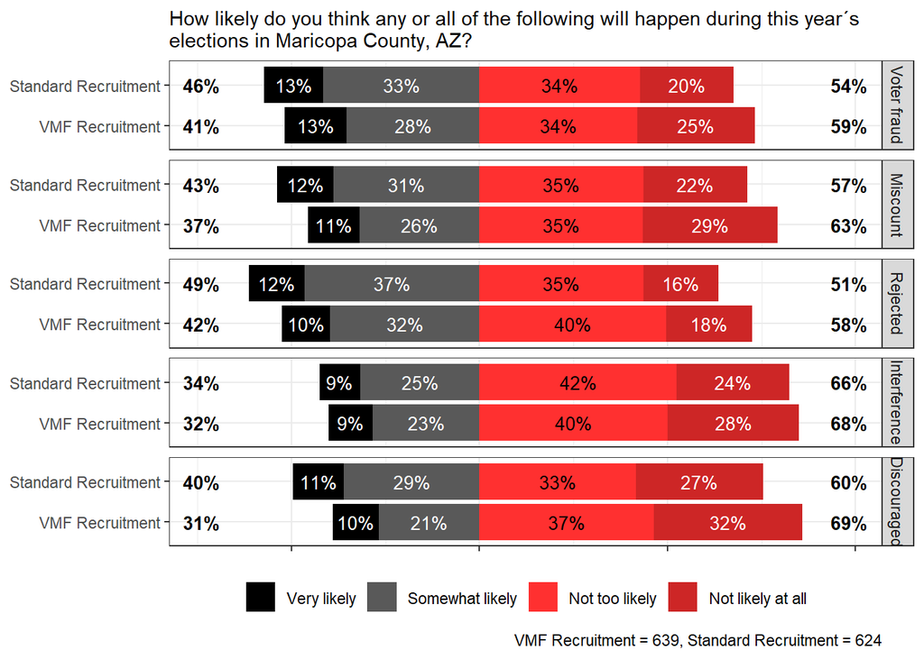

As Figure 13 illustrates, **those in the VMF Recruitment condition were more likely to say that voter fraud was “Not likely at all” by 5 percentage points (p<0.025). The percentage saying that election officials will try to discourage people from voting was not likely to occur in Maricopa County was 8 percentage points higher among those who read that veterans and military family members would be part of the elections workforce** (p<0.01), with a shift of about 4 points among both those saying “Not too likely” and “Not likely at all”.

Additionally, in the VMF Recruitment condition the percentage saying that it was “Not likely at all” that many votes will not actually be counted was nearly 7 percentage points higher (p<0.01), with a similar increase in the percentage saying it was not likely (“Not too likely” and “Not likely at all”) that many people will show up and be told they are not eligible (p<0.01).

When we asked about the likelihood that a foreign country would tamper with votes in Maricopa County, AZ a larger percentage of those in the VMF Recruitment condition said this was “Not likely at all” by 4 percentage points (p<0.07).

## Impacts on Confidence

**Note**

This section is subject to change.

We asked respondents to report how various features of election administration would: 1) influence their confidence in the fairness and accuracy of elections this November; and 2) influence their confidence that voters would be safe from violence, threats of violence, or intimidation while voting in-person this election.

These questions were more general as they did not reference any particular place.

One of the primary objectives was to determine whether recruiting veterans was preferable to recruiting lawyers and college students, two other groups that are commonly discussed as potential additions to the elections workforce.

Our evidence is clear: **public confidence would increase more when veterans and their family members are part of the elections staff and volunteers compared to when election staff is said to include lawyers or college students.**

### Impact on confidence in fairness and accuracy of elections

Survey participants responded to six statements, all prefaced with the following,

> “Regardless of whether any of these are actually the case, how would the following impact your confidence in the fairness and accuracy of elections conducted this November?”
1. Election officials test every machine used in the election to ensure they are secure.
2. Election officials conduct audits of ballots after every election to confirm the results were accurate.
3. Poll watchers affiliated with the political parties or candidates observe the election.
4. Election staff and volunteers include military veterans and their family members from the community[^4].
5. Election staff and volunteers include lawyers from the community.
6. Election staff and volunteers include college students from the community.

For each statement, survey participants responded by selecting one of five response options:

1. Decrease confidence a lot
2. Decrease confidence somewhat
3. No impact on confidence
4. Increase confidence somewhat
5. Increase confidence a lot

The primary interest concerned whether confidence in election fairness would increase or decrease based on the composition of election staff and volunteers. Of particular importance are responses to the statement which asked respondents to consider whether inclusion of military veterans and veteran’s family members as election staff and volunteers has any impact on their confidence in the fairness and accuracy of elections in November.

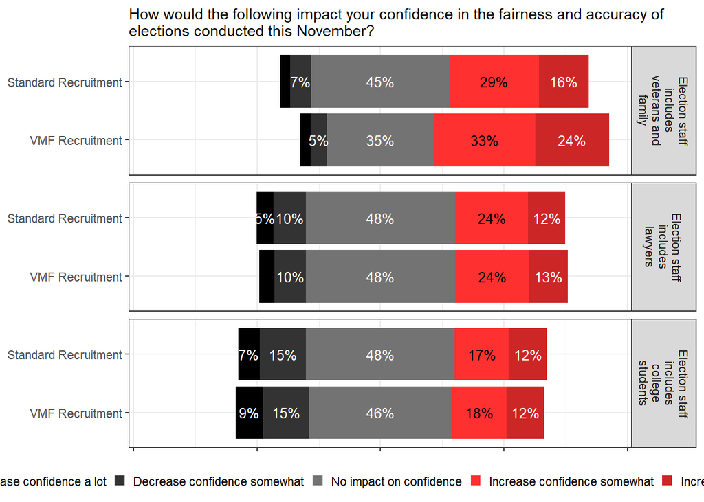

Figure 14: Impact on Confidence in Election Fairness and Accuracy by Condition (VMF recruitment vs. Standard Recruitment)

Results displayed in Figure 14 suggest that county efforts to recruit veterans as election staff and volunteers does more to increase one’s confidence in the fairness and accuracy of elections regardless of the experimental condition. That is, even for those who were in the *control* group, respondents reported that the inclusion of veterans and their family members as election staff and volunteers would increase confidence in the fairness and accuracy of elections more than when election staff includes lawyers or college students. This increase in confidence was 9% percentage points higher compared to when lawyers are included as election staff, and 16% percentage points higher than when election staff and volunteers are said to include college students.

Moreover, Figure 14 demonstrates a clear boost in confidence when election staff includes veterans and family members, especially for those who were in the treatment group. The percentage of people who said their confidence in election fairness would increase when election staff includes veterans was about 11.6% percentage points higher than those who said the same in the control group.

These results suggest that county efforts to recruit veterans as election staff and volunteers does more to increase one’s confidence in the fairness and accuracy of elections, especially under the prospect that election staff and volunteers would include veterans and their family members.

These results suggest that reading a vignette about county efforts to recruit veterans as election staff and volunteers does more to increase one’s confidence in the fairness and accuracy of elections, especially under the prospect that election staff and volunteers would include veterans and their family members.

[^4]: Two different versions of this statement was presented to survey participants. Half of the sample read the statement as, “Election staff and volunteers *include* military veterans and their family members from the community”, whereas the other half of the sample read, “The *majority* of election staff and volunteers consist of military veterans and their family members from the community.” No significant differences in responses were observed between those who read one version of the statement over the other. However, the same was done for statements number 5 and 6 which concern “lawyers from the community” and “college students from the community”. Significant differences were found when comparing responses between the different versions of these statements. See the appendix for further discussion on these results.

### Impact on Confidence in Voter Safety at polling sites

The same analysis was conducted for questions that assessed the reported impact on confidence that voters would be safe to vote in-person. Survey participants provided responses to the same six statements as before, which were all prefaced with the following question,

> “How would the following impact your confidence that voters are safe from violence, threats of violence, or intimidation while voting in-person during elections this November?”

Again, the bar graph below displays a clear boost among participants in the treatment group who reported that their confidence in voter safety would increase when election staff is said to include veterans and their family members.

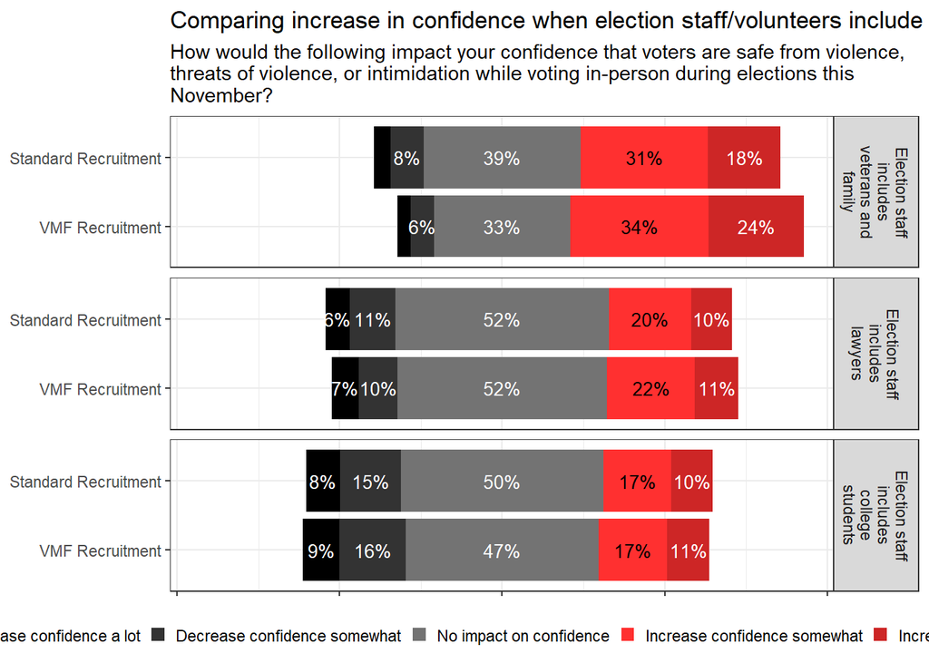

Figure 15: Impact on Confidence in Voter Safety at Polling Sites by Condition (VMF recruitment vs. Standard Recruitment)

The proportion of people who said their confidence in voter safety would increase when election staff includes veterans was about 8.4 percentage points higher than those who said the same in the control group.

# Sample Demographics and Balance

Table 1: Survey sample Demographic characteristics

| **Variable** | **N** | **Overall** N = 1,263<sup>1</sup> | **Standard Recruitment** N = 624<sup>1</sup> | **VMF Recruitment** N = 639<sup>1</sup> |
| --- | --- | --- | --- | --- |
| Age group, in years | 1,263 |  |  |  |
| 18-24 |  | 107 (8.5%) | 56 (9.0%) | 51 (8.0%) |
| 25-34 |  | 234 (19%) | 107 (17%) | 127 (20%) |
| 35-44 |  | 251 (20%) | 130 (21%) | 121 (19%) |
| 45-54 |  | 223 (18%) | 113 (18%) | 110 (17%) |
| 55-64 |  | 239 (19%) | 124 (20%) | 115 (18%) |
| 65-74 |  | 144 (11%) | 70 (11%) | 74 (12%) |
| 75-84 |  | 56 (4.4%) | 20 (3.2%) | 36 (5.6%) |
| 85-92 |  | 9 (0.7%) | 4 (0.6%) | 5 (0.8%) |
| What is your current gender? | 1,263 |  |  |  |
| Male |  | 592 (47%) | 285 (46%) | 307 (48%) |
| Female |  | 655 (52%) | 329 (53%) | 326 (51%) |
| Other/Refused |  | 16 (1.3%) | 10 (1.6%) | 6 (0.9%) |
| Primary race reported by respondent | 1,263 |  |  |  |
| White or Caucasian |  | 969 (77%) | 476 (76%) | 493 (77%) |
| Black or African American |  | 161 (13%) | 82 (13%) | 79 (12%) |
| American Indian |  | 22 (1.7%) | 10 (1.6%) | 12 (1.9%) |
| Asian |  | 56 (4.4%) | 26 (4.2%) | 30 (4.7%) |
| Other |  | 55 (4.4%) | 30 (4.8%) | 25 (3.9%) |
| Highest level of education completed | 1,263 |  |  |  |
| Less than high school degree |  | 34 (2.7%) | 20 (3.2%) | 14 (2.2%) |
| High school graduate (high school diploma or equivalent including GED) |  | 326 (26%) | 152 (24%) | 174 (27%) |
| Some college but no degree |  | 281 (22%) | 141 (23%) | 140 (22%) |
| Associate degree in college (2-year) |  | 137 (11%) | 69 (11%) | 68 (11%) |
| Bachelor's degree in college (4-year) |  | 322 (25%) | 166 (27%) | 156 (24%) |
| Master's degree |  | 130 (10%) | 61 (9.8%) | 69 (11%) |
| Doctoral degree |  | 18 (1.4%) | 5 (0.8%) | 13 (2.0%) |
| Professional degree (JD, MD) |  | 15 (1.2%) | 10 (1.6%) | 5 (0.8%) |
| Party ID 3 categories, with true Independents | 1,262 |  |  |  |
| Republican |  | 537 (43%) | 261 (42%) | 276 (43%) |
| Democrat |  | 565 (45%) | 282 (45%) | 283 (44%) |
| Independent |  | 160 (13%) | 81 (13%) | 79 (12%) |
| Turnout 2020 | 1,263 |  |  |  |
| Didn't vote |  | 246 (19%) | 129 (21%) | 117 (18%) |
| Unsure/Ineligible |  | 101 (8.0%) | 49 (7.9%) | 52 (8.1%) |
| Voted |  | 916 (73%) | 446 (71%) | 470 (74%) |
| Who did you vote for? | 1,018 |  |  |  |
| Donald Trump |  | 436 (43%) | 214 (43%) | 222 (43%) |
| Joe Biden |  | 524 (51%) | 252 (51%) | 272 (52%) |
| Other |  | 58 (5.7%) | 30 (6.0%) | 28 (5.4%) |
| Do you plan to vote? | 1,263 |  |  |  |
| Yes |  | 1,032 (82%) | 500 (80%) | 532 (83%) |
| No |  | 110 (8.7%) | 56 (9.0%) | 54 (8.5%) |
| Undecided |  | 121 (9.6%) | 68 (11%) | 53 (8.3%) |
| Have you ever served in the Armed Forces? | 1,263 |  |  |  |
| Yes |  | 121 (9.6%) | 53 (8.5%) | 68 (11%) |
| No |  | 1,142 (90%) | 571 (92%) | 571 (89%) |
| Are you now serving in the Armed Forces? | 121 |  |  |  |
| Yes |  | 15 (12%) | 5 (9.4%) | 10 (15%) |
| No |  | 106 (88%) | 48 (91%) | 58 (85%) |
| Member of immediate family served or is currently serving | 1,263 |  |  |  |
| Yes |  | 438 (35%) | 215 (34%) | 223 (35%) |
| No |  | 825 (65%) | 409 (66%) | 416 (65%) |

'true' Independents do not identify nor 'lean' toward either political party  
<sup>1</sup> n (%)

# Appendix: Survey Experiment Vignettes

### Treatment Vignette

**Local Military Veterans Recruited for Election Jobs in Maricopa County**  
PHOENIX (AP) — Election officials in Maricopa County, Arizona, announced a program designed to recruit military veterans and their family members from the community to serve as election administrators, including election polling place workers, temporary workers, and full-time staff. As the U.S. general elections in November near, election officials must fill several thousand temporary positions and hundreds of other open positions to ensure sufficient staffing for the 2024 elections and beyond.  
Army veteran Jordan Braxton just joined the elections workforce. Jordan believes their role is important to ensuring a secure, accurate, and transparent election, “Many places are short on staff this election cycle. I served my country in the Army, and I want to do my part as a veteran and a citizen to ensure that everyone trusts the process and the outcome of the election.”

(a) Text of the Treatment Condition: Recruitment of Veterans and Military Family Members

### Control Vignette

**Local Residents Recruited for Election Jobs in Maricopa County**  
PHOENIX (AP) —Election officials in Maricopa County, Arizona, announced a program to recruit members of the community to serve as election administrators, including election polling place workers, temporary workers, and full-time staff. As the U.S. general elections in November near, election officials must fill several thousand temporary positions and hundreds of other open positions to ensure sufficient staffing for the 2024 elections and beyond.  
Jordan Braxton just joined the elections workforce. Jordan believes their role is important to ensuring a secure, accurate, and transparent election, “Many places are short on staff this election cycle. I want to do my part as a citizen to ensure that everyone trusts the process and the outcome of the election.”

(b) Text of the Control Condition: Recruitment of Community Members

Figure 16: Fabricated Article Vignettes utilized as Experimental Stimulus